# 1. Why Deep Learning Needs Physics?

# 7. Inverse Problem: Unknown Parameter Estimation

We explore the capabilities of PINNs as a neural network-driven approach for solving forward problems. However, as previously discussed, this method does not demonstrate clear advantages over traditional computational techniques. On the other hand, the use of PINNs for inverse problem-solving presents a promising avenue for advancing scientific computing.

Here, we focus on the inverse problem of not only predicting the flow field around a cylinder but also identifying unknown parameters from observed data. By integrating observational data with governing physical equations, PINNs provide a powerful framework for solving these problems while maintaining consistency with known scientific principles.

## 7.1. Problem Setup

Now, we will solve an inverse problem using PINN

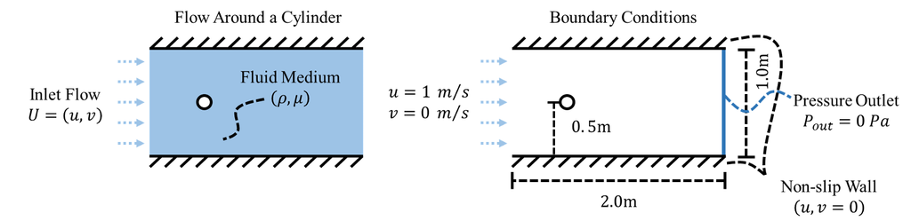

- Unknown properties

$$\rho = ? \quad \mu = ?$$

- Partial differential equations & boundary conditions

$$ \color{red}\rho\left(u\frac{\partial u}{\partial x} + v\frac{\partial u}{\partial y} + \frac{1}{\color{red}\rho}\frac{\partial p}{\partial x} \right) - \color{red}\mu\left( \frac{\partial^2u}{\partial^2 x} + \frac{\partial^2u}{\partial^2 y}\right) = 0$$
$$ \color{red}\rho\left(u\frac{\partial v}{\partial x} + v\frac{\partial v}{\partial y} + \frac{1}{\color{red}\rho}\frac{\partial p}{\partial y} \right) - \color{red}\mu\left( \frac{\partial^2v}{\partial^2 x} + \frac{\partial^2v}{\partial^2 y}\right) = 0$$

- Inlet boundary condition ($x=-0.5$):

$$u|_{x = -0.5} = 1$$

- Outlet boundary condition ($x=1.5$):

$$v|_{x = 1.5} = 0$$$$p|_{x = 1.5} = 0$$

- Non-slip boundary condition ($y=\pm 0.5$):

$$u|_{y = \pm 0.5} = 0$$$$v|_{y = \pm 0.5} = 0$$

Make a neural network and loss functions like below :

[figure not shown]

## 7.2. Solve the Inverse Problem

**Import Library**

```python
import torch
import matplotlib.pyplot as plt
import numpy as np
import warnings
warnings.filterwarnings("ignore")

# true values
C1true = 1.0
C2true = 0.01

device = torch.device('cuda:0' if torch.cuda.is_available() else 'cpu')
print(device)
```

```
cuda:0
```

**Load the Data**

- [lab3_XY_domain](https://drive.google.com/file/d/1V6wUNUirlaW7aZ4Hx4SMmxZJpqFeFA_B/view?usp=sharing)
- [lab3_gt_domain](https://drive.google.com/file/d/1r5sFfiRRVQgVXliwa6KB6rBBZlxoZeDw/view?usp=sharing)

```python
Y_domain= np.load('/content/drive/MyDrive/DL/DL_data/lab3_XY_domain.npy')
gt_domain = np.load('/content/drive/MyDrive/DL/DL_data/lab3_gt_domain.npy')
print(Y_domain.shape)
print(gt_domain.shape)
```

```
(19692, 2)
(19692, 3)
```

**Define Collocation Points**

```python
'Boundary Conditions'
bc_top_x = np.linspace(-0.5, 1.5, 200).reshape(-1, 1)
bc_top_y = 0.5 * np.ones_like(bc_top_x).reshape(-1, 1)

bc_bottom_x = np.linspace(-0.5, 1.5, 200).reshape(-1, 1)
bc_bottom_y = -0.5 * np.ones_like(bc_bottom_x).reshape(-1, 1)

bc_inlet_y = np.linspace(-0.5, 0.5, 100).reshape(-1, 1)
bc_inlet_x = -0.5 * np.ones_like(bc_inlet_y).reshape(-1, 1)

bc_outlet_y = np.linspace(-0.5, 0.5, 100).reshape(-1, 1)
bc_outlet_x = 1.5 * np.ones_like(bc_outlet_y).reshape(-1, 1)

Y_top = np.concatenate((bc_top_x, bc_top_y), 1)
Y_bottom = np.concatenate((bc_bottom_x, bc_bottom_y), 1)
Y_inlet = np.concatenate((bc_inlet_x, bc_inlet_y), 1)
Y_outlet = np.concatenate((bc_outlet_x, bc_outlet_y), 1)

radius = 0.05
theta = np.linspace(0, 2 * np.pi, 200)
bc_cylinder_x = (0 + radius * np.cos(theta)).reshape(-1, 1)
bc_cylinder_y = (0 + radius * np.sin(theta)).reshape(-1, 1)
Y_cylinder = np.concatenate((bc_cylinder_x, bc_cylinder_y), 1)

Y_wall = np.concatenate((Y_top, Y_bottom, Y_cylinder))
```

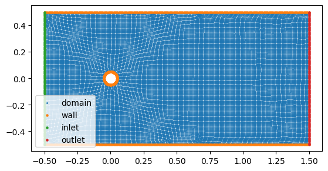

```python
plt.scatter(Y_domain[:, 0], Y_domain[:, 1], s = 1, label = 'domain')
plt.scatter(Y_wall[:, 0], Y_wall[:, 1], s = 5, label = 'wall')
plt.scatter(Y_inlet[:, 0], Y_inlet[:, 1], s = 5, label = 'inlet')
plt.scatter(Y_outlet[:, 0], Y_outlet[:, 1], s = 5, label = 'outlet')
plt.axis('scaled')
plt.legend()
plt.show()
```

**Define Observation Points**

- This CFD data is where the density $\rho$ is 1 and the viscosity $\mu$ is 0.01.
- Of course, these two values are assumed to be unknown throughout this example.
- Also, assume that 49 sensor locations are randomly selected.
- Assume that x-velocity, y-velocity, and pressure are available at these locations.

```
Y obs: (49, 2)
GT obs: (49, 3)
```

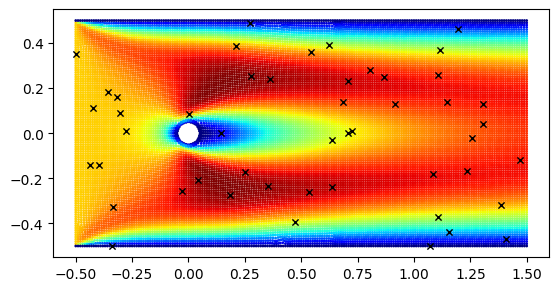

```python
idx_obs = np.random.choice(len(Y_domain), int(0.0025 * len(Y_domain)), replace = False)
Y_obs = Y_domain[idx_obs]
gt_obs = gt_domain[idx_obs]
print('Y obs: {}'.format(Y_obs.shape))
print('GT obs: {}'.format(gt_obs.shape))

plt.scatter(Y_domain[:, 0], Y_domain[:, 1], c = gt_domain[:, 0], s = 1, cmap = 'jet')
plt.scatter(Y_obs[:, 0], Y_obs[:, 1], marker = 'x', linewidths = 1, s = 20, c = 'k')
plt.axis('scaled')
plt.show()
```

**Define PINN Network**

```python
import torch.nn as nn
from torch.nn import Linear, Tanh

class PINN(nn.Module):
    def __init__(self):
        super(PINN, self).__init__()
        self.net = nn.Sequential(
        Linear(2, 256),
        Tanh(),
        Linear(256, 256),
        Tanh(),
        Linear(256, 256),
        Tanh(),
        Linear(256, 256),
        Tanh(),
        Linear(256, 3),
        )

        self._initialize_weights()

    def _initialize_weights(self):
        for m in self.modules():
            if isinstance(m, nn.Linear):
                nn.init.xavier_normal_(m.weight)
                nn.init.zeros_(m.bias)

    def forward(self, x):
        x = x.float()
        output = self.net(x)
        v1, v2, p = output[:, 0:1], output[:, 1:2], output[:, 2:3]
        return v1, v2, p
```

```python
from IPython.display import clear_output

def PLOT(model, Y_domain, rho_list, vis_list):
    pred = model(Y_domain)

    plt.figure(figsize = (9, 2))
    plt.subplot(1, 3, 1)
    plt.title('CFD')
    plt.scatter(Y_domain[:, 0].detach().cpu().numpy(),
                Y_domain[:, 1].detach().cpu().numpy(),
                c = gt_domain[:, 0],
                s = 0.1, cmap = 'jet')
    plt.axis('scaled')

    plt.subplot(1, 3, 2)
    plt.title('Prediction')
    plt.scatter(Y_domain[:, 0].detach().cpu().numpy(),
                Y_domain[:, 1].detach().cpu().numpy(),
                c = pred[0].detach().cpu().numpy(),
                s = 0.1, cmap = 'jet')
    plt.axis('scaled')

    plt.subplot(1, 3, 3)
    plt.title('Error')
    plt.scatter(Y_domain[:, 0].detach().cpu().numpy(),
                Y_domain[:, 1].detach().cpu().numpy(),
                c = np.abs(pred[0].detach().cpu().numpy() - gt_domain[:, 0:1]),
                s = 0.1, cmap = 'jet')
    plt.axis('scaled')
    plt.tight_layout()
    plt.show()

    plt.figure(figsize = (6, 2))
    plt.subplot(1, 2, 1)
    plt.title('Rho Prediction')
    plt.plot(rho_list)

    plt.subplot(1, 2, 2)
    plt.title('Vis Prediction')
    plt.plot(vis_list)
    plt.tight_layout()
    plt.show()
    clear_output(wait = True)
```

**Define Functions to Compute Physics Loss**

```python
def derivative(y, t):
    df = torch.autograd.grad(y, t, grad_outputs = torch.ones_like(y).to(device), create_graph = True)[0]
    df_x = df[:, 0:1]
    df_y = df[:, 1:2]
    return df_x, df_y

def requires_grad(x):
    return torch.tensor(x, dtype = torch.float32, requires_grad = True).to(device)
```

**Define PDE**

2D Navier-Stokes Equations & boundary conditions (for steady state)

$$ \begin{align*} \rho \left(u{\partial u \over \partial x} + v{\partial u \over \partial y} + {1 \over \rho}{\partial p \over \partial x}\right) - \mu \ \left({\partial^2 u \over {\partial x^2}} + {\partial^2 u \over {\partial y^2}}\right) &= 0\\\\ \rho \left(u{\partial v \over \partial x} + v{\partial v \over \partial y} + {1 \over \rho}{\partial p \over \partial y}\right) - \mu \ \left({\partial^2 v \over {\partial x^2}} + {\partial^2 v \over {\partial y^2}}\right) &= 0\\\\ {\partial u \over \partial x} + {\partial v \over \partial y} &= 0 \end{align*} $$

```python
def PDE(model, Y_domain):

    v1, v2, p = model(Y_domain)

    dv1_x, dv1_y = derivative(v1, Y_domain)
    dv1_xx, _ = derivative(dv1_x, Y_domain)
    _, dv1_yy =  derivative(dv1_y, Y_domain)

    dv2_x, dv2_y = derivative(v2, Y_domain)
    dv2_xx, _ = derivative(dv2_x, Y_domain)
    _, dv2_yy = derivative(dv2_y, Y_domain)

    dp_x, dp_y = derivative(p, Y_domain)

    pde_v1 = rho * (v1 * dv1_x + v2 * dv1_y) + dp_x - vis * (dv1_xx + dv1_yy)
    pde_v2 = rho * (v1 * dv2_x + v2 * dv2_y) + dp_y - vis * (dv2_xx + dv2_yy)
    pde_cont = dv1_x + dv2_y

    return pde_v1, pde_v2, pde_cont
```

**Boundary Conditions**

- Two Dirichlet boundary conditions on the plate boundary (no-slip condition),

$$u(x,y) = 0, \quad v(x,y) = 0 \qquad \text{at} \quad y = \frac{D}{2} \ \; \text{or} \; -\frac{D}{2}$$

- Two Dirichlet boundary conditions at the cylinder boundary

$$u(\text{cylinder}) = 0, \quad v(\text{cylinder}) = 0$$

- Two Dirichlet boundary conditions at the inlet boundary

- Two Dirichlet boundary conditions at the outlet boundary

```python
def BC_wall(model, Y_wall):
    v1_wall, v2_wall, _ = model(Y_wall)
    return v1_wall, v2_wall

def BC_inlet(model, Y_inlet):
    v1_inlet, v2_inlet, _ = model(Y_inlet)
    v1_inlet = v1_inlet - torch.ones_like(v1_inlet).to(device)
    return v1_inlet, v2_inlet

def BC_outlet(model, Y_outlet):
    _, v2_outlet, p_outlet = model(Y_outlet)
    return v2_outlet, p_outlet
```

**Parameters to be Optimized**

All we need to do is to define the unknown parameters, specifically $\rho$ (density) and $v$ (viscosity), as trainable variables within the PINN.

```python
# Initialize \rho and \mu as NumPy arrays with the value 1.
rho = torch.ones(1).to(device).requires_grad_(True).float()
vis = torch.ones(1).to(device).requires_grad_(True).float()

model = PINN().to(device)
optimizer = torch.optim.Adam([{'params': model.parameters(), 'lr': 1e-4},
                              {'params': rho, 'lr': 1e-4},
                              {'params': vis, 'lr': 1e-4}])
loss_fn = nn.MSELoss()
```

**Train**

$$ \begin{align*} \mathcal{L} &= \omega_{\text{data}} \mathcal{L}_{\text{data}} + \omega_{\text{PDE}} \mathcal{L}_{\text{PDE}} + \omega_{\text{BC}} \mathcal{L}_{\text{BC}}\\\\\\ \mathcal{L}_{\text{data}} &= \frac{1}{N_{\text{data}}} \sum \left( \left(u - \hat u \right)^2 + \left(v - \hat v \right)^2 + \left(p - \hat p \right)^2 \right) \\ \end{align*} $$

```python
epoch = 0
best_loss = np.inf
loss_list = []
rho_list, vis_list = [], []
```

```python
## Requires grad
Y_domain = requires_grad(Y_domain)
Y_wall = requires_grad(Y_wall)
Y_inlet = requires_grad(Y_inlet)
Y_outlet = requires_grad(Y_outlet)
Y_obs = requires_grad(Y_obs)
gt_obs = requires_grad(gt_obs)

while epoch < 50001:
    ## PDE loss
    PDE_v1, PDE_v2, PDE_cont = PDE(model, Y_domain)
    loss_PDE_v1 = loss_fn(PDE_v1, torch.zeros_like(PDE_v1))
    loss_PDE_v2 = loss_fn(PDE_v2, torch.zeros_like(PDE_v2))
    loss_PDE_cont = loss_fn(PDE_cont, torch.zeros_like(PDE_cont))
    loss_pde = loss_PDE_v1 + loss_PDE_v2 + loss_PDE_cont

    ## BC loss
    v1_wall, v2_wall = BC_wall(model, Y_wall)
    v1_inlet, v2_inlet = BC_inlet(model, Y_inlet)
    v2_outlet, p_outlet = BC_outlet(model, Y_outlet)

    loss_BC_wall_u = loss_fn(v1_wall, torch.zeros_like(v1_wall))
    loss_BC_wall_v = loss_fn(v2_wall, torch.zeros_like(v2_wall))
    loss_BC_inlet_u = loss_fn(v1_inlet, torch.zeros_like(v1_inlet))
    loss_BC_inlet_v = loss_fn(v2_inlet, torch.zeros_like(v2_inlet))
    loss_BC_outlet_v = loss_fn(v2_outlet, torch.zeros_like(v2_outlet))
    loss_BC_outlet_p = loss_fn(p_outlet, torch.zeros_like(p_outlet))
    loss_bc = loss_BC_wall_u + loss_BC_wall_v + loss_BC_inlet_u + loss_BC_inlet_v + loss_BC_outlet_v + loss_BC_outlet_p

    u_obs, v_obs, p_obs = model(Y_obs)
    loss_data_u = loss_fn(u_obs, gt_obs[:, 0:1])
    loss_data_v = loss_fn(v_obs, gt_obs[:, 1:2])
    loss_data_p = loss_fn(p_obs, gt_obs[:, 2:3])
    loss_data = loss_data_u + loss_data_v + loss_data_p

    loss = loss_pde + loss_bc + 10 * loss_data

    optimizer.zero_grad()
    loss.backward()
    optimizer.step()

    loss_list.append(loss.item())
    rho_list.append(rho.item())
    vis_list.append(vis.item())

    if epoch % 1000 == 0:
        print('EPOCH : %6d/%6d | Loss_PDE : %5.4f | Loss_BC : %5.4f | Loss_DATA : %5.4f | RHO : %.4f | VIS : %.4f' \
                %(epoch, 50000, loss_pde.item(), loss_bc.item(), loss_data.item(), rho.item(), vis.item()))
        PLOT(model, Y_domain, rho_list, vis_list)

    epoch += 1
```

**Result**

Load the model parameters

- [lab3.pt](https://drive.google.com/file/d/1Xo4TEQSWBbQc5LTVfCfSE4gz7SKoKIOZ/view?usp=sharing)
- [rho_list](https://drive.google.com/file/d/10QtJVX9F5oRvoTuoIgQAH6A90NIjnHm9/view?usp=sharing)
- [vis_list](https://drive.google.com/file/d/1R5_Vt6yDAqKXI0bDbml_glwMphxQoSrg/view?usp=sharing)

```
Predicted RHO: 0.9962, Predicted VIS: 0.0100
```

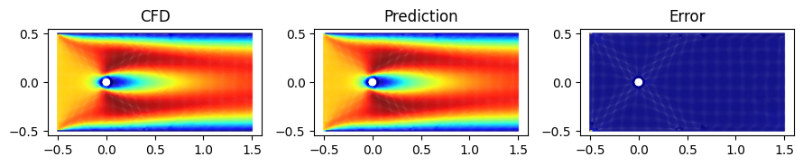

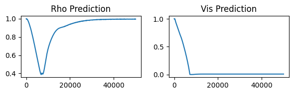

```python
rho_list = np.load('/content/drive/MyDrive/DL/DL_data/rho_list.npy', allow_pickle = True).tolist()
vis_list = np.load('/content/drive/MyDrive/DL/DL_data/vis_list.npy', allow_pickle = True).tolist()

with torch.no_grad():
    print('Predicted RHO: {:.4f}, Predicted VIS: {:.4f}\n\n'.format(rho_list[-1], vis_list[-1]))
    model = torch.load('/content/drive/MyDrive/DL/DL_data/lab3.pt')
    PLOT(model, Y_domain, rho_list, vis_list)
```

# 8. Inverse Problem: Unknown Boundary Condition Estimation

Another common type of inverse problem involves unknown boundary conditions. Here, we will consider a 2D heat transfer problem where one of the boundary conditions is not known. By leveraging PINNs, we can infer the missing boundary condition using observed temperature data while ensuring consistency with the governing heat equation.

## 8.1 Problem Setup

Now, we will predict the unknown boundary condition using PINN in solving the 2D heat transfer equation.

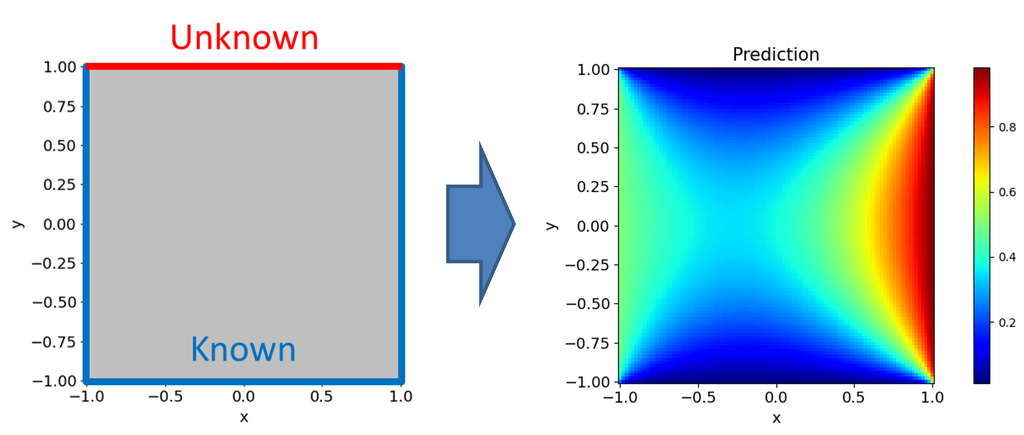

- Problem properties

$$ \kappa = 1 $$

- Partial differential equations & boundary conditions

$$ \kappa \left(\frac{\partial^2 T}{\partial x^2} + \frac{\partial^2 T}{\partial y^2} \right) = 0$$

- Left boundary condition ($x=-1$):

$$T|_{x = -1} = 0.5$$

- Right boundary condition ($x=1$):

$$T|_{x = 1} = 1$$

- Bottom boundary condition ($y = -1$):

$$T|_{y = -1} = 0$$

- The top boundary condition $(y = 1)$ is unknown.

$$T|_{y = 1} = \; ?$$

Make a neural network and loss functions like below:

[figure not shown]

## 8.2 Solve the Inverse Problem

**Import Library**

```python
import torch
import matplotlib.pyplot as plt
import numpy as np
import warnings
warnings.filterwarnings("ignore")

device = torch.device('cuda:0' if torch.cuda.is_available() else 'cpu')
print(device)
```

```
cuda:0
```

**Load the Data**

- [lab4_gt_domain](https://drive.google.com/file/d/1m3Xgeta3zOP7paUYwQ6C8w2pt9m16huu/view?usp=sharing)

```python
gt_domain = np.load('/content/drive/MyDrive/DL/DL_data/lab4_gt_domain.npy')
```

**Define Observation Points**

Assume that nine thermometers are positioned at specific locations as shown below. These thermometers provide observed temperature data, which will be used to infer the unknown boundary condition in the 2D heat transfer problem.

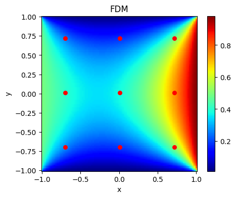

```python
plt.figure(figsize = (5, 4))
x = np.linspace(-1, 1, 100)
y = np.linspace(-1, 1, 100)
x, y = np.meshgrid(x, y)

idx_xs = np.array([15, 50, 85])
idx_ys = np.array([15, 50, 85])

Y_obs = []
gt_obs = []
for idx_x in idx_xs:
    for idx_y in idx_ys:
        Y_obs.append(np.concatenate((x[idx_x, idx_y].reshape(-1, 1),
                                      y[idx_x, idx_y].reshape(-1, 1)), 1)[0, :])
        gt_obs.append(gt_domain[idx_x, idx_y])

Y_obs = np.array(Y_obs)
gt_obs = np.array(gt_obs).reshape(-1, 1)

plt.pcolormesh(x, y, gt_domain, cmap = 'jet')
plt.colorbar()
plt.scatter(Y_obs[:, 0], Y_obs[:, 1], s = 30, c = 'r', cmap = 'jet')
plt.title('FDM')
plt.xlabel('x')
plt.ylabel('y')
plt.axis("square")
plt.show()
```

**Define Collocation Points**

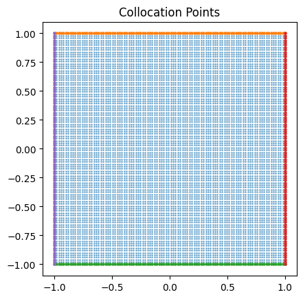

```python
# 'Domain Points'
x = np.linspace(-1, 1, 100)
y = np.linspace(-1, 1, 100)
x, y = np.meshgrid(x, y)
Y_domain = np.concatenate((x.reshape(-1, 1), y.reshape(-1, 1)), 1)

# 'Boundary Conditions'
bc_top_x = np.linspace(-1, 1, 100).reshape(-1, 1)
bc_top_y = np.ones_like(bc_top_x)

bc_bottom_x = np.linspace(-1, 1, 100).reshape(-1, 1)
bc_bottom_y = -1 * np.ones_like(bc_bottom_x)

bc_right_y = np.linspace(-1, 1, 100).reshape(-1, 1)
bc_right_x = np.ones_like(bc_right_y)

bc_left_y = np.linspace(-1, 1, 100).reshape(-1, 1)
bc_left_x = -1 * np.ones_like(bc_left_y)

Y_top = np.concatenate((bc_top_x, bc_top_y), 1)
Y_bottom = np.concatenate((bc_bottom_x, bc_bottom_y), 1)
Y_right = np.concatenate((bc_right_x, bc_right_y), 1)
Y_left = np.concatenate((bc_left_x, bc_left_y), 1)

plt.scatter(Y_domain[:, 0], Y_domain[:, 1], s = 1, alpha = 0.5)
plt.scatter(Y_top[:, 0], Y_top[:, 1], s = 5)
plt.scatter(Y_bottom[:, 0], Y_bottom[:, 1], s = 5)
plt.scatter(Y_right[:, 0], Y_right[:, 1], s = 5)
plt.scatter(Y_left[:, 0], Y_left[:, 1], s = 5)
plt.title('Collocation Points')
plt.axis('scaled')
plt.show()
```

**Define PINN Network**

```python
import torch.nn as nn
from torch.nn import Linear, Tanh

class PINN(nn.Module):
    def __init__(self):
        super(PINN, self).__init__()
        self.net = nn.Sequential(
        Linear(2, 256),
        Tanh(),
        Linear(256, 256),
        Tanh(),
        Linear(256, 256),
        Tanh(),
        Linear(256, 256),
        Tanh(),
        Linear(256, 1),
        )

        self._initialize_weights()

    def _initialize_weights(self):
        for m in self.modules():
            if isinstance(m, nn.Linear):
                nn.init.xavier_normal_(m.weight)
                nn.init.zeros_(m.bias)

    def forward(self, x):
        x = x.float()
        return self.net(x)

model = PINN().to(device)
optimizer = torch.optim.Adam(model.parameters(), lr=1e-4)
loss_fn = nn.MSELoss()
```

```python
from IPython.display import clear_output

def PLOT(model_test, Y_domain):

    pred = model_test(Y_domain)

    plt.figure(figsize = (9, 2.3))
    plt.subplot(1, 3, 1)
    plt.title('CFD')
    plt.scatter(Y_domain[:, 0].detach().cpu().numpy(),
                Y_domain[:, 1].detach().cpu().numpy(),
                c = gt_domain.detach().cpu().numpy().reshape(-1, 1),
                vmin = 0, vmax = 1, s = 1, cmap = 'jet')
    plt.colorbar()
    plt.axis('scaled')

    plt.subplot(1, 3, 2)
    plt.title('Prediction')
    plt.scatter(Y_domain[:, 0].detach().cpu().numpy(),
                Y_domain[:, 1].detach().cpu().numpy(),
                c = pred.detach().cpu().numpy(),
                vmin = 0, vmax = 1, s = 1, cmap = 'jet')
    plt.colorbar()
    plt.axis('scaled')

    plt.subplot(1, 3, 3)
    plt.title('Error')
    plt.scatter(Y_domain[:, 0].detach().cpu().numpy(),
                Y_domain[:, 1].detach().cpu().numpy(),
                c = np.abs(pred.detach().cpu().numpy() - np.array(gt_domain.detach().cpu().numpy().reshape(-1, 1))),
                vmin = 0, vmax = 0.2, s = 1, cmap = 'jet')
    plt.colorbar()
    plt.axis('scaled')
    plt.tight_layout()
    plt.show()
    clear_output(wait=True)
```

**Define Functions to Compute Physics Loss**

```python
def derivative(y, t):
    df = torch.autograd.grad(y, t, grad_outputs = torch.ones_like(y).to(device), create_graph = True)[0]
    df_x = df[:, 0:1]
    df_y = df[:, 1:2]
    return df_x, df_y

def requires_grad(x):
    return torch.tensor(x, dtype = torch.float32, requires_grad = True).to(device)
```

**Define Governing Equation and Three Known Boundary Conditions**

```python
def PDE(model, Y_domain):
    T = model(Y_domain)

    dT_x, dT_y = derivative(T, Y_domain)
    dT_xx, _ = derivative(dT_x, Y_domain)
    _, dT_yy = derivative(dT_y, Y_domain)

    pde = 1 * (dT_xx + dT_yy)
    return pde

def BC_bottom(model, Y_bottom):
    T_bottom = model(Y_bottom)
    return T_bottom

def BC_right(model, Y_right):
    T_right = model(Y_right)
    T_right = T_right - torch.ones_like(T_right).to(device)
    return T_right

def BC_left(model, Y_left):
    T_left = model(Y_left)
    T_left = T_left - 0.5 * torch.ones_like(T_left).to(device)
    return T_left
```

**Train**

```python
## Requires grad
Y_domain = requires_grad(Y_domain)
Y_obs = requires_grad(Y_obs)
Y_bottom = requires_grad(Y_bottom)
Y_right = requires_grad(Y_right)
Y_left = requires_grad(Y_left)
Y_top = requires_grad(Y_top)
gt_domain = requires_grad(gt_domain)
gt_obs = requires_grad(gt_obs)

best_loss = np.inf

for epoch in range(20001):

    ## PDE loss
    pde_term = PDE(model, Y_domain)
    loss_pde = loss_fn(pde_term, torch.zeros_like(pde_term))

    ## BC loss
    T_bottom = BC_bottom(model, Y_bottom)
    T_right = BC_right(model, Y_right)
    T_left = BC_left(model, Y_left)

    loss_BC_bottom = loss_fn(T_bottom, torch.zeros_like(T_bottom))
    loss_BC_right = loss_fn(T_right, torch.zeros_like(T_right))
    loss_BC_left = loss_fn(T_left, torch.zeros_like(T_left))

    loss_bc = loss_BC_bottom + loss_BC_right + loss_BC_left

    loss = loss_pde + loss_bc

    optimizer.zero_grad()
    loss.backward()
    optimizer.step()

    if epoch % 1000 == 0:
        print('EPOCH : %6d/%6d| Loss : %5.4f | Loss_PDE : %5.4f | Loss_BC : %5.4f' \
                %(epoch, epochs-1, loss.item(), loss_pde.item(), loss_bc.item()))
        PLOT(model, Y_domain)
```

**Result**

As shown, the prediction deviates significantly from the CFD ground truth due to the absence of one boundary condition. It is important to note that most conventional computational methods fail to produce meaningful results unless all boundary conditions are fully specified.

In contrast, PINNs can still generate a solution by minimizing the loss function, even though the inferred result may not be entirely accurate. This behavior is somewhat analogous to the case of multiple solutions in a system of linear equations, where an underdetermined system can still yield a set of possible solutions that satisfy the given constraints.

Load the model parameters

- [lab4_wo_data.pt](https://drive.google.com/file/d/1l_SNAH6wZ4uU6n9zJCPHhHf-zP6RLTNi/view?usp=sharing)

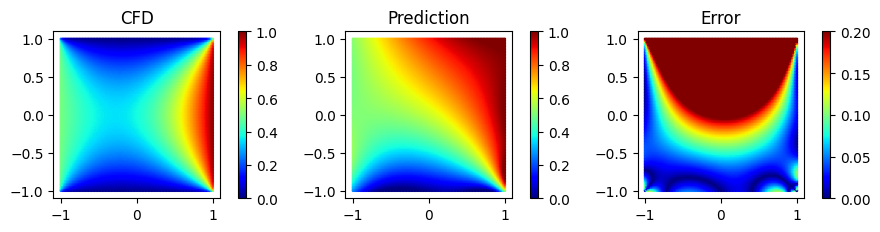

```python
with torch.no_grad():
    model = torch.load('/content/drive/MyDrive/DL/DL_data/lab4_wo_data.pt')
    PLOT(model, Y_domain)
```

## 8.3. Using Observed Data for Predicting Unknown Boundary Condition

We incorporate additional observed data from nine sensors to provide PINN with more information, enhancing its ability to infer the missing boundary condition. This scenario is analogous to finding the best approximate solution in a system of linear equations, where an overdetermined system - having more equations than unknowns - allows for an optimized solution that best satisfies the given constraints.

**Train with data**

```python
model = PINN().to(device)
optimizer = torch.optim.Adam(model.parameters(), lr = 1e-4)
loss_fn = nn.MSELoss()
```

```python
best_loss = np.inf

for epoch in range(20001):

    ## PDE loss
    pde_term = PDE(model, Y_domain)
    loss_pde = loss_fn(pde_term, torch.zeros_like(pde_term))

    ## BC loss
    T_bottom = BC_bottom(model, Y_bottom)
    T_right = BC_right(model, Y_right)
    T_left = BC_left(model, Y_left)

    loss_BC_bottom = loss_fn(T_bottom, torch.zeros_like(T_bottom))
    loss_BC_right = loss_fn(T_right, torch.zeros_like(T_right))
    loss_BC_left = loss_fn(T_left, torch.zeros_like(T_left))

    loss_bc = loss_BC_bottom + loss_BC_right + loss_BC_left

    ## Data loss
    T_obs = model(Y_obs)
    loss_data = loss_fn(T_obs, gt_obs)

    loss = loss_pde + loss_bc + loss_data

    optimizer.zero_grad()
    loss.backward()
    optimizer.step()

    if epoch % 1000 == 0:
        print('EPOCH : %6d/%6d| Loss : %5.4f | Loss_PDE : %5.4f | Loss_BC : %5.4f | Loss_DATA : %5.4f' \
                %(epoch, epochs-1, loss.item(), loss_pde.item(), loss_bc.item(), loss_data.item()))
        PLOT(model, Y_domain)
```

**Result**

The results demonstrate improved predictions, although they still do not perfectly match the ground truth. One approach to enhance accuracy is to place additional sensors to provide more observed data. However, beyond simply increasing the number of sensors, other methods could further improve the solution.

Load the model parameters

- [lab4_w_data.pt](https://drive.google.com/file/d/1XhDcuYUke9QREU_O5SXPNzrJ764MPm1u/view?usp=sharing)

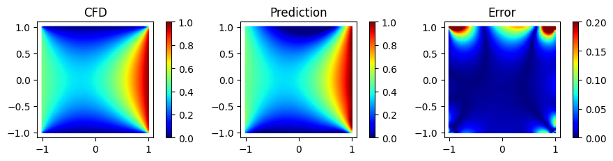

```python
with torch.no_grad():
    model = torch.load('/content/drive/MyDrive/DL/DL_data/lab4_w_data.pt')
    PLOT(model, Y_domain)
```

## 8.4 Using Observed Data and Prior Knowledge

To make this example more interesting, let's assume that we have prior knowledge that the temperature at the missing boundary is unknown but constant. This additional information can be incorporated into the PINN framework as an additional constraint, improving its ability to infer a more accurate solution.

**Train again using both data and prior knowledge**

```python
model = PINN().to(device)
optimizer = torch.optim.Adam(model.parameters(), lr = 1e-4)
loss_fn = nn.MSELoss()
```

```python
for epoch in range(20001):

    ## PDE loss
    pde_term = PDE(model, Y_domain)
    loss_pde = loss_fn(pde_term, torch.zeros_like(pde_term))

    ## BC loss
    T_bottom = BC_bottom(model, Y_bottom)
    T_right = BC_right(model, Y_right)
    T_left = BC_left(model, Y_left)

    loss_BC_bottom = loss_fn(T_bottom, torch.zeros_like(T_bottom))
    loss_BC_right = loss_fn(T_right, torch.zeros_like(T_right))
    loss_BC_left = loss_fn(T_left, torch.zeros_like(T_left))

    loss_bc = loss_BC_bottom + loss_BC_right + loss_BC_left

    ## Data loss
    T_obs = model(Y_obs)
    loss_data = loss_fn(T_obs, gt_obs)

    ## Prior Knowledge
    T_top = model(Y_top)
    mean_value = torch.mean(T_top)
    loss_prior = loss_fn(T_top, mean_value)

    loss = loss_pde + loss_bc + loss_data + loss_prior

    optimizer.zero_grad()
    loss.backward()
    optimizer.step()

    if epoch % 1000 == 0:
        print('EPOCH : %6d/%6d| Loss : %5.4f | Loss_PDE : %5.4f | Loss_BC : %5.4f | Loss_DATA : %5.4f | Loss_PRIOR : %5.4f' \
                %(epoch, epochs - 1, loss.item(), loss_pde.item(), loss_bc.item(), loss_data.item(), loss_prior.item()))
        PLOT(model, Y_domain)
```

**Load the model parameters**

- [lab4_w_prior.pt](https://drive.google.com/file/d/1CG57hG9LrJWn1CQJYzOGOWum5y4jl6-a/view?usp=sharing)

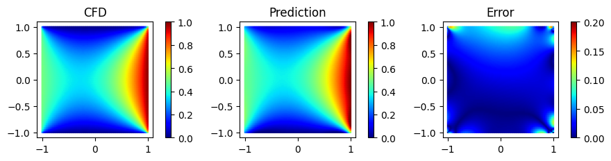

```python
with torch.no_grad():
    model = torch.load('/content/drive/MyDrive/DL/DL_data/lab4_w_prior.pt')
    PLOT(model, Y_domain)
```

**Result**

It is clearly observed that the final prediction is the most accurate among the three different scenarios. The key takeaways from this example are as follows:

- Understanding the PINN Framework - We explored how PINNs can integrate physics-based constraints, observed data, and prior knowledge, demonstrating their flexibility in solving inverse problems.
- Strategic Problem-Solving in Engineering - When addressing complex engineering challenges, start by assessing the availability of data. Then, consider leveraging additional forms of knowledge — such as physical laws, boundary conditions, or empirical insights — beyond just raw data to enhance predictive accuracy and reliability.

## 8.5 Comparison of Each Model

To evaluate the model's performance more precisely, we plot the predicted temperature along the top boundary. This visualization allows for a direct comparison between the predicted and ground truth values, providing deeper insights into how well the model captures the missing boundary condition.

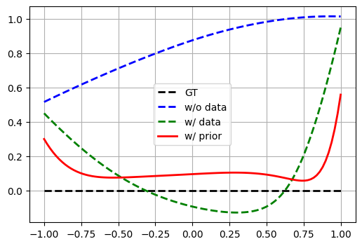

```python
with torch.no_grad():
    model_wo_data = torch.load('/content/drive/MyDrive/DL/DL_data/lab4_wo_data.pt')
    model_w_data = torch.load('/content/drive/MyDrive/DL/DL_data/lab4_w_data.pt')
    model_w_prior = torch.load('/content/drive/MyDrive/DL/DL_data/lab4_w_prior.pt')

    y_top = Y_top[:,0].detach().cpu().numpy()
    GT = np.zeros_like(y_top)
    T_wo_data = model_wo_data(Y_top)
    T_w_data = model_w_data(Y_top)
    T_w_prior = model_w_prior(Y_top)

    plt.figure(figsize = (6, 4))
    plt.plot(y_top, GT, c = 'k', linestyle = '--', linewidth = 2, label = 'GT')
    plt.plot(y_top, T_wo_data.detach().cpu().numpy(), c = 'b', linestyle = '--', linewidth = 2, label = 'w/o data')
    plt.plot(y_top, T_w_data.detach().cpu().numpy(), c = 'g', linestyle = '--', linewidth = 2, label = 'w/ data')
    plt.plot(y_top, T_w_prior.detach().cpu().numpy(), c = 'r', linewidth = 2, label = 'w/ prior')
    plt.legend()
    plt.grid(True)
    plt.show()
```

```python
%%javascript
$.getScript('https://kmahelona.github.io/ipython_notebook_goodies/ipython_notebook_toc.js')
```